# Benchmark Methods & Forecast Accuracy

In this tutorial, you will learn general tools that are useful for many different forecasting situations. It will describe some methods for benchmark forecasting, methods for checking whether a forecasting model has adequately utilized the available information, and methods for measuring forecast accuracy. Each of the tools discussed in this tutorial will be used repeatedly in subsequent tutorials as you develop and explore a range of forecasting methods.

## tl;df

This tutorial serves as an introduction to basic benchmarking approaches for time series data and covers:

1. Replication requirements: What you’ll need to reproduce the analysis.
2. Naive Forecasting Methods: A simple but useful benchmark approach.
3. Fitted Values and Residuals: Always check the residuals.
4. Training and Test Sets: How to partition time series data.
5. Evaluating Forecast Accuracy: How to evaluate accuracy of non-seasonal and non-season forecast methods.
6. Time Series Cross-validation: A more sophisticated approach for evaluating predictive accuracy.
7. Exercises: Practice what you’ve learned.

## Replication Requirements

This tutorial leverages a variety of data sets to illustrate unique time series features. The data sets are all provided by the `forecast` and `fpp2` packages. Furthermore, these packages provide various functions for computing and visualizing basic time series components.

```r
library(forecast)
library(fpp2)
```

## Naive Forecasting Methods

Although it is tempting to apply “sophisticated” forecasting methods, one must remember to consider *naive forecasts*. A naive forecast is simply the most recently observed value. In other words, at the time *t*, the *k*-step-ahead naive forecast ($F_{t+k}$) equals the observed value at time *t* ($y_t$).

$$F_{t+k} = y_t \tag{1}$$

Sometimes, this is the best that can be done for many time series including most stock price data (for reasons illustrated in the previous tutorial’s exercise). Even if it is not a good forecasting method, it provides a useful benchmark for other forecasting methods. We can perform a naive forecast with the `naive` function.

Here, we use `naive` to forecast the next 10 values. The resulting output is an object of class `forecast`. This is the core class of objects in the forecast package, and there are many functions for dealing with them. We can print off the model summary with `summary`, which provides us with the residual standard deviation, some error measures (which we will cover later), and the actual forecasted values.

```r
fc_goog <- naive(goog, 10)
summary(fc_goog)
```

```
Forecast method: Naive method

Model Information:
Call: naive(y = goog, h = 10)

Residual sd: 8.9145

Error measures:
                    ME     RMSE      MAE        MPE      MAPE MASE       ACF1
Training set 0.4436236 8.921089 6.008889 0.06493981 0.9815741    1 0.04680557

Forecasts:
     Point Forecast    Lo 80    Hi 80    Lo 95    Hi 95
1001         838.96 827.5272 850.3928 821.4750 856.4450
1002         838.96 822.7915 855.1285 814.2325 863.6875
1003         838.96 819.1577 858.7623 808.6751 869.2449
1004         838.96 816.0943 861.8257 803.9900 873.9300
1005         838.96 813.3954 864.5246 799.8623 878.0577
1006         838.96 810.9554 866.9646 796.1306 881.7894
1007         838.96 808.7116 869.2084 792.6990 885.2210
1008         838.96 806.6231 871.2969 789.5049 888.4151
1009         838.96 804.6615 873.2585 786.5050 891.4150
1010         838.96 802.8062 875.1138 783.6675 894.2525
```

You will notice the forecast output provides a point forecast (the last observed value in the `goog` data set) and prediction confidence levels at the 80% and 95% level. A prediction interval gives an interval within which we expect $y_i$ to lie with a specified probability. For example, assuming the forecast errors are uncorrelated and normally distributed, then a simple 95% prediction interval for the next observation in a time series is

$$\hat y_t \pm 1.96 \hat{\sigma} \tag{2}$$

where $\hat{\sigma}$ is an estimate of the standard deviation of the forecast distribution. In forecasting, it is common to calculate 80% intervals and 95% intervals, although any percentage may be used.

When forecasting one-step ahead, the standard deviation of the forecast distribution is almost the same as the standard deviation of the residuals. (In fact, the two standard deviations are identical if there are no parameters to be estimated such as with the naive method. For forecasting methods involving parameters to be estimated, the standard deviation of the forecast distribution is slightly larger than the residual standard deviation, although this difference is often ignored.)

For example, consider our naive forecast for the `goog` data. The last value of the observed series is 838.96, so the forecast of the next value is 838.96 and the standard deviation of the residuals from the naive method is 8.91. Hence, a 95% prediction interval for the next value of `goog` is

$$838.96 \pm 1.96(8.91) = [821, 856].$$

Similarly, an 80% prediction interval is given by

$$838.96 \pm 1.28(8.91) = [828, 850].$$

The value of prediction intervals is that they express the uncertainty in the forecasts. If we only produce point forecasts, there is no way of telling how accurate the forecasts are. But if we also produce prediction intervals, then it is clear how much uncertainty is associated with each forecast. Thus, with the naive forecast on the next `goog` value, we can be 80% confident that the next value will be in the range of 828-850 and 95% confident that the the value will be between 821-856.

We can illustrate this prediction interval by plotting the naive model (`fc_goog`). Here, we see the black point estimate line flat-line (equal to the last observed value) and the colored bands represent our 80% and 95% prediction confidence interval. A common feature of prediction intervals is that they increase in length as the forecast horizon increases. The further ahead we forecast, the more uncertainty is associated with the forecast, and so the prediction intervals grow wider.[^1]

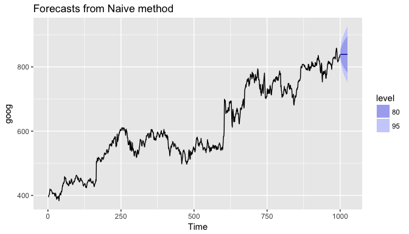

```r
# forecast next 25 values
fc_goog <- naive(goog, 25)
autoplot(fc_goog)
```

For seasonal data, a related idea is to use the corresponding season from the last year of data. For example, if you want to forecast the sales volume for next March, you would use the sales volume from the previous March. For a series with *M* seasons, we can write this as

$$F_{t+k} = y_{t-M+k} \tag{3}$$

This is implemented in the `snaive` function, meaning, *seasonal naive.* Here I use `snaive` to forecast the next 16 values for the `ausbeer` series. Here we see that the 4th quarter for each future year is 488 which is the last observed 4th quarter value in 2009.

```r
fc_beer <- snaive(ausbeer, 16)
summary(fc_beer)
```

```
Forecast method: Seasonal naive method

Model Information:
Call: snaive(y = ausbeer, h = 16)

Residual sd: 19.1207

Error measures:
                   ME     RMSE      MAE      MPE    MAPE MASE       ACF1
Training set 3.098131 19.32591 15.50935 0.838741 3.69567    1 0.01093868

Forecasts:
        Point Forecast    Lo 80    Hi 80    Lo 95    Hi 95
2010 Q3            419 394.2329 443.7671 381.1219 456.8781
2010 Q4            488 463.2329 512.7671 450.1219 525.8781
2011 Q1            414 389.2329 438.7671 376.1219 451.8781
2011 Q2            374 349.2329 398.7671 336.1219 411.8781
2011 Q3            419 383.9740 454.0260 365.4323 472.5677
2011 Q4            488 452.9740 523.0260 434.4323 541.5677
2012 Q1            414 378.9740 449.0260 360.4323 467.5677
2012 Q2            374 338.9740 409.0260 320.4323 427.5677
2012 Q3            419 376.1020 461.8980 353.3932 484.6068
2012 Q4            488 445.1020 530.8980 422.3932 553.6068
2013 Q1            414 371.1020 456.8980 348.3932 479.6068
2013 Q2            374 331.1020 416.8980 308.3932 439.6068
2013 Q3            419 369.4657 468.5343 343.2438 494.7562
2013 Q4            488 438.4657 537.5343 412.2438 563.7562
2014 Q1            414 364.4657 463.5343 338.2438 489.7562
2014 Q2            374 324.4657 423.5343 298.2438 449.7562
```

Similar to `naive`, we can plot the `snaive` model with autoplot.

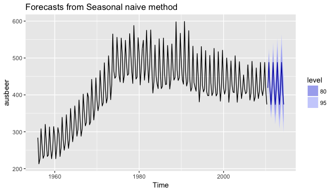

```r
autoplot(fc_beer)
```

## Fitted Values and Residuals

When applying a forecasting method, it is important to always check that the residuals are well-behaved (i.e., no outliers or patterns) and resemble white noise. Essential assumptions for an appropriate forecasting model include residuals being:

- uncorrelated
- centered at mean zero

Furthermore, the prediction intervals are computed assuming that the residuals:

- have constant variance
- are normally distributed

A convenient function to use to check these assumptions is the `checkresiduals` function. This function produces a time plot, ACF plot, histogram, and a Ljung-Box test on the residuals. Here, I use `checkresiduals` for the `fc_goog` naive model. We see that the top plot shows residuals that appear to be white noise (no discernable pattern), the bottom left plot shows only a couple lags that exceed the 95% confidence interval, bottom right plot shows the residuals to be approximately normally distributed, and the Ljung-Box test results give a p-value of 0.22 suggesting the residuals are white noise. This is a good thing as it suggests that are model captures all (or most) of the available signal in the data.

```
    Ljung-Box test

data:  residuals
Q* = 13.061, df = 10, p-value = 0.2203

Model df: 0.   Total lags used: 10
```

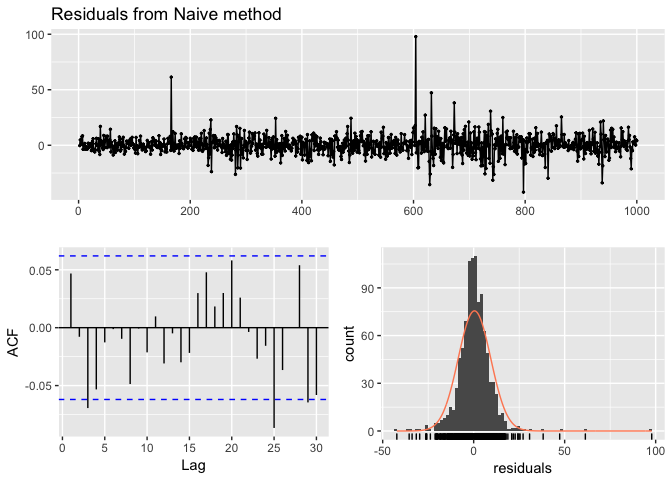

```r
checkresiduals(fc_goog)
```

If we compare that to the `fc_beer` seasonal naive model we see that there is an apparent pattern in the residual time series plot, the ACF plot shows several lags exceeding the 95% confidence interval, and the Ljung-Box test has a statistically significant p-value suggesting the residuals are not purely white noise. This suggests that there may be another model or additional variables that will better capture the remaining signal in the data.

```
    Ljung-Box test

data:  residuals
Q* = 60.535, df = 8, p-value = 3.661e-10

Model df: 0.   Total lags used: 8
```

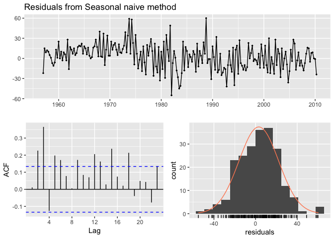

```r
checkresiduals(fc_beer)
```

## Training & Test Sets

A training set is a data set that is used to discover possible relationships. A test set is a data set that is used to verify the strength of these potential relationships. When you separate a data set into these parts, you generally allocate more of the data for training, and less for testing. There is one important difference between data partitioning in cross-sectional and time series data. In cross-sectional data the partitioning is usually done randomly, with a random set of observations designated as training data and the remainder as test data. However, in time series, a random partition creates two problems:

1. It does not mimic the temporal uncertainty where we use the past and present to forecast the future.
2. It creates two time series with “holes”, whereas many standard forecasting methods cannot handle time series with missing values.

Therefore, time series partitioning into training and test sets is done by taking a training partition from earlier observations and then using a later partition for the test set.

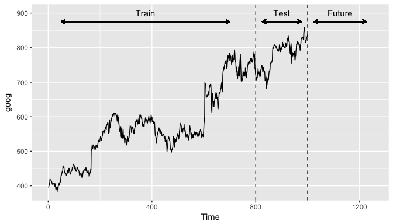

One function that can be used to create training and test sets is `subset.ts()`, which returns a subset of a time series where the start and end of the subset are specified using *index* values. The `gold` time series comprises daily gold prices over 1108 trading days. Let’s use the first 1000 days as a training set. We can also create a test data set of the remaining data.

```r
train <- subset.ts(gold, end = 1000)
test <- subset.ts(gold, start = 1001, end = length(gold))
```

A similar approach can be used for data where we want to maintain season features. For example, if we use `subset.ts` to take the first 1,000 observations this may include half of a year in the training data and the other half in the test data. Rather, for forecasting methods that include seasonal features (i.e. `snaive`), we prefer to not split a full cycle of seasons (i.e. year, month, week). We can use the `window` function to do this. For example, the `ausbeer` data set has quarterly data from 1956-2010. Here, we take data from 1956 through the 4th quarter of 1995 to be a `train`ing data set.

```r
train2 <- window(ausbeer, end = c(1995, 4))
```

The `window` function is also particularly useful when we want to take data from a defined period. For example, if we decide that data from 1956-1969 is not appropriate due to regulatory changes then we can create a training data set from the 1st qtr of 1970 through the 4th qtr of 1995.

```r
train3 <- window(ausbeer, start = c(1970, 1), end = c(1995, 4))
```

## Evaluating Forecast Accuracy

For evaluating predictive performance, several measures are commonly used to assess the predictive accuracy of a forecasting method. In all cases, *the measures are based on the test data set*, which serves as a more objective basis than the training period to assess predictive accuracy. Given a forecast and it’s given errors ($e_t$), the commonly used accuracy measures are listed below:

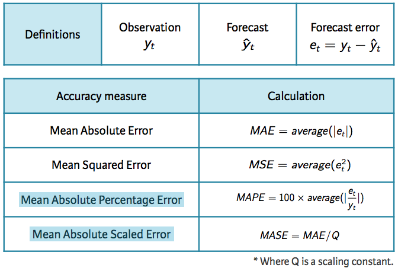

Note that each measure has its strengths and weaknesses. For example, if you want to compare forecast accuracy between two series on very different scales you can’t compare the MAE or MSE for these forecast as these measures depend on the scale of the time series data. MAPE is often better for comparisons but only if our data are all positive and have no zeros or small values. It also assumes a natural zero so it can’t be used for temperature forecasts as these are based on arbitrary zero scales. MASE is similar to MAE but is scaled so that it can be compared across different data series. You can read more about each of these measures [here](https://www.otexts.org/fpp/2/5); however, for now just keep in mind that for all these measures a smaller value signifies a better forecast.

### Evaluating forecast accuracy of *non-seasonal* methods

We can compute all of these measures by using the `accuracy` function. The accuracy measures provided also include *root mean squared error* (RMSE) which is the square root of the mean squared error (MSE). Minimizing RMSE, which corresponds with increasing accuracy, is the same as minimizing MSE. In addition, other accuracy measures not illustrated above are also provided (i.e. ACF1 - autocorrelation at lag 1; [Theil’s U](https://en.wikipedia.org/wiki/Uncertainty_coefficient)). The output of `accuracy` allows us to compare these accuracy measures for the residuals of the training data set against the forecast errors of the test data. However, our main concern is how well different forecasting methods improve the predictive accuracy on the test data.

Using the training data we created from the `gold` data set (`train`), let’s create two different forecasts:

1. A `naive` forecast and
2. a forecast equal to the mean of all observations

Here, I use `h = 108` to predict for the next 108 days (note that the `gold` data set has 1108 observations, the `train`ing data set has 1000, so we want to predict the next 108 observations and compare that to the test data.).

```r
# create training data
train <- subset.ts(gold, end = 1000)
# Compute naive forecasts and save to naive_fc
naive_fc <- naive(train, h = 108)
# Compute mean forecasts and save to mean_fc
mean_fc <- meanf(train, h = 108)
# Use accuracy() to compute forecast accuracy
accuracy(naive_fc, gold)
```

```
                      ME     RMSE       MAE         MPE     MAPE MASE       ACF1 Theil's U
Training set  0.09161392  6.33977  3.158386  0.01662141 0.794523    1 -0.3098928        NA
Test set     -6.53834951 15.84236 13.638350 -1.74622688 3.428789   NA  0.9793153  5.335899
```

```r
accuracy(mean_fc, gold)
```

```
                        ME     RMSE      MAE       MPE      MAPE     MASE      ACF1 Theil's U
Training set -4.239671e-15 59.17809 53.63397 -2.390227 14.230224 16.98145 0.9907254        NA
Test set      1.319363e+01 19.55255 15.66875  3.138577  3.783133       NA 0.9793153  6.123788
```

What `accuracy` is doing is taking the model output from the training data (`naive_fc` & `mean_fc`) and computing the accuracy measures of the 108 forecasted values to those values in `gold` that are not included in the model (aka test data). This means we do not need to directly feed it a test data set, although we do have that option as illustrated below:

```r
train <- subset.ts(gold, end = 1000)
test <- subset.ts(gold, start = 1001, end = length(gold))
naive_fc <- naive(train, h = 108)
accuracy(naive_fc, test)
```

```
                      ME     RMSE       MAE         MPE     MAPE MASE       ACF1 Theil's U
Training set  0.09161392  6.33977  3.158386  0.01662141 0.794523    1 -0.3098928        NA
Test set     -6.53834951 15.84236 13.638350 -1.74622688 3.428789   NA  0.9793153  5.335899
```

If we compare the test set accuracy measures for both models we see that the naive approach has lower scores across all measures indicating *better* forecasting accuracy.

### Evaluating forecast accuracy of *seasonal* methods

We can use a similar approach to evaluate the accuracy of seasonal forecasting models. The primary difference is we want to use the `window` function for creating our `train`ing data so that we appropriately capture seasonal cycles. Here, I illustrate with the `ausbeer` data set. We see the snaive model produces lower scores across all measures indicating *better* forecasting accuracy.

```r
# create training data
train2 <- window(ausbeer, end = c(1995, 4))
# create specific test data of interest
test <- window(ausbeer, start = c(1996, 1), end = c(2004, 4))
# Compute snaive forecasts and save to snaive_fc
snaive_fc <- snaive(train2, h = length(test))
# Compute mean forecasts and save to mean_fc
mean_fc <- meanf(train2, h = length(test))
# Use accuracy() to compute forecast accuracy
accuracy(snaive_fc, test)
```

```
                    ME     RMSE      MAE       MPE     MAPE      MASE        ACF1 Theil's U
Training set  4.730769 20.60589 16.51282  1.284697 3.957622 1.0000000  0.01783674        NA
Test set     -8.527778 18.06854 13.08333 -2.011727 3.038430 0.7923137 -0.39101873 0.2890478
```

```r
accuracy(mean_fc, test)
```

```
                        ME     RMSE      MAE       MPE      MAPE     MASE        ACF1 Theil's U
Training set -2.279427e-14 96.37835 78.64437 -6.646984 21.996740 4.762625  0.72972747        NA
Test set      2.393472e+01 49.38745 34.07500  4.640789  7.243654 2.063548 -0.09479634 0.8164006
```

## Time Series Cross-validation

A more sophisticated version of training/test sets is cross-validation. You can see how cross-validation works for cross-sectional data here. For time series data, the procedure is similar but the training set consists only of observations that occurred *prior* to the observation that forms the test set. So in traditional time series partitioning, we select a certain point in time where everything before that point (blue) is the training data and everything after that point (red) is the test data.

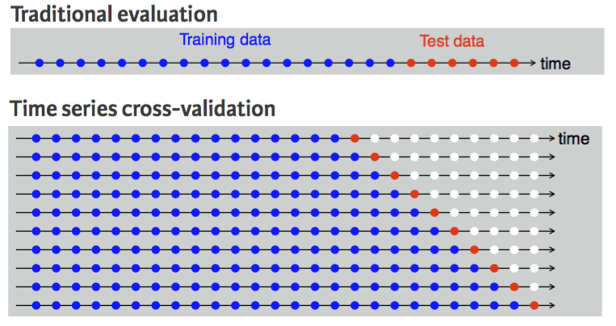

However, assuming we want to perform a 1-step forecast (predicting the next value in the series), time series cross-validation will:

1. Select the observations at, and prior to, time *k* (blue dots).
2. Select the observation at $k+1$ for the test data (red dot).
3. Discard the observations at $k+2,k+3,\dots, k+n$ (white dots).
4. Compute the error on the forecast for time $k+1$.
5. Repeat steps 1-4 above for $i = 1,2,\dots,T-k$ where *T* is the total number of observations.
6. Compute the forecast accuracy measures based on the errors obtained.

This procedure is sometimes known as a *“rolling forecasting origin”* because the *“origin”* ($k+i−1$) at which the forecast is based rolls forward in time as displayed by each row in the above illustration.

With time series forecasting, one-step forecasts may not be as relevant as multi-step forecasts. In this case, the cross-validation procedure based on a rolling forecasting origin can be modified to allow multi-step errors to be used. Suppose we are interested in models that produce good *h*-step-ahead forecasts. Here, we simply adjust the above algorithm so that we select the observation at time $k+h+i−1$ for the test set, use the observations at times $1,2,\dots,k+i−1$ to estimate the forecasting model, compute the *h*-step error on the forecast for time $k+h+i−1$, rinse & repeat until we can compute the forecasting accuracy for all errors calculated. For a 2-step-ahead forecast this looks like:

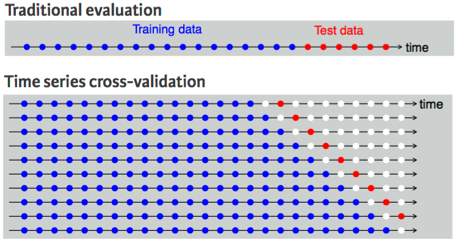

This seems tedious, however, there is a simple function that implements this procedure. The `tsCV` function applies a forecasting model to a sequence of training sets from a given time series and provides the errors as the output. However, we need to compute our own accuracy measures with these errors.

As an example, let’s perform a cross-validation approach for a 1-step ahead (`h=1`) `naive` model with the `goog` data. We can then compute the MSE which is 79.59.

```r
errors <- tsCV(goog, forecastfunction = naive, h = 1)
mean(errors^2, na.rm = TRUE)
```

```
[1] 79.58582
```

We can compute and compare the MSE for different forecast horizons (1-10) to see if certain forecasting horizons perform better than others. Here, we see that as the forecasting horizon extends the predictive accuracy becomes poorer.

```r
# create empty vector to hold MSE values
MSE <- vector("numeric", 10)
for(h in 1:10) {
  errors <- tsCV(goog, forecastfunction = naive, h = h)
  MSE[h] <- mean(errors^2, na.rm = TRUE)
}
MSE
```

```
 [1]  79.58582 167.14427 253.92996 330.20539 398.47090 464.83012 531.09256 596.40191 654.25322 712.70988
```

## Exercises

Using the built-in `AirPassengers` data set:

1. Partition your data into a training set that includes 1949-1959 and a test set that includes all months in 1960.
2. Examine time plots of the training data set.
3. Perform a naive and seasonal naive model on the training data.
4. Assess the residuals of these models. Do either models meet the required assumptions? Do they appear to be white noise or can you still see a pattern in the residuals?
5. Whether or not the model assumptions appear to be violated, compare the forecasting accuracy of these models to the values in the test data. Which model provides greater forecasting accuracy?
6. Using the entire `AirPassengers` data set, perform a time series cross validation that:
   - Uses the model in exercise 5 that produces the best forecasting accuracy.
   - Computes and compares the MSE for different forecast horizons (1-8).
   - Which time horizon produces the lowest MSE?
[^1]: There are some exceptions to this. For example, some non-linear forecasting methods do not have this attribute.